# Biometría I - Examen Parcial I

# BIOMETRÍA I

## Examen Parcial I

**Nombre:** ____________________________________

**Fecha:** ______________________________________

**Sección:** _____________________________________

**Valor Total: 80 puntos**

### Instrucciones

- Seleccione la mejor contestación.
- Cada pregunta vale 2 puntos.
- No se permite calculadora.
- Marque una sola respuesta por pregunta.

# I. Conceptos Fundamentales

### 1.

¿Cuál es el propósito principal de la estadística?

A. Organizar, resumir e interpretar datos

B. Reducir la variación observada en una población

C. Sustituir la necesidad de recopilar datos

D. Confirmar que una hipótesis es correcta

### 2.

Una población es:

A. El conjunto de individuos seleccionados para estudio

B. Todos los individuos u observaciones de interés

C. El subconjunto utilizado para estimar parámetros

D. Los individuos incluidos en una muestra aleatoria

### 3.

Una muestra es:

A. El conjunto completo de observaciones de interés

B. Un valor calculado a partir de datos

C. Un subconjunto de la población seleccionado para estudio

D. Una característica medida en cada individuo

### 4.

¿Cuál situación requiere el uso de estadística?

A. Identificar una especie desconocida

B. Medir una sola planta

C. Clasificar organismos taxonómicamente

D. Comparar el crecimiento de dos grupos utilizando datos

### 5.

La bioestadística se utiliza principalmente para:

A. Analizar datos biológicos

B. Estudiar únicamente reacciones químicas

C. Analizar exclusivamente fenómenos astronómicos

D. Diseñar instrumentos de laboratorio

# II. Variables y Tipos de Datos

### 6.

¿Cuál es una variable cuantitativa continua?

A. Altura de una planta

B. Tipo de suelo

C. Color de pétalos

D. Especie observada

### 7.

¿Cuál es una variable cuantitativa discreta?

A. Longitud de una hoja

B. Temperatura ambiental

C. Número de semillas producidas

D. Peso seco

### 8.

¿Cuál es una variable nominal?

A. Color de flor

B. Nivel educativo

C. Altura de una planta

D. Número de semillas

### 9.

¿Cuál es una variable ordinal?

A. Especie observada

B. Nivel educativo

C. Peso corporal

D. Número de hojas

### 10.

¿Cuál variable puede tomar valores decimales?

A. Número de estudiantes

B. Número de flores

C. Cantidad de frutos

D. Altura de una planta

# III. Muestreo

### 11.

El objetivo principal del muestreo es:

A. Eliminar la variabilidad

B. Obtener información sobre una población utilizando un subconjunto

C. Sustituir completamente a la población

D. Garantizar resultados exactos

### 12.

¿Cuál es una ventaja del muestreo aleatorio?

A. Reduce la posibilidad de sesgo de selección

B. Garantiza que todos los individuos sean incluidos

C. Elimina la variación natural de la población

D. Produce muestras idénticas en cada estudio

### 13.

Una muestra representativa es aquella que:

A. Refleja adecuadamente las características de la población

B. Tiene el mismo tamaño que la población

C. Contiene únicamente individuos extremos

D. Produce la media más alta

### 14.

Seleccionar únicamente amigos para una encuesta es un ejemplo de:

A. Muestreo estratificado

B. Muestreo sistemático

C. Muestreo aleatorio simple

D. Muestreo sesgado

### 15.

Un censo consiste en estudiar:

A. Una muestra aleatoria

B. Todos los individuos de la población

C. Solamente individuos disponibles

D. Una fracción representativa

# IV. Tablas de Frecuencia

### 16.

¿Cuál es la principal función de una tabla de frecuencia?

A. Organizar y resumir observaciones

B. Calcular hipótesis

C. Estimar causalidad

D. Eliminar errores experimentales

### 17.

La frecuencia absoluta corresponde a:

A. El porcentaje de individuos en una categoría

B. El porcentaje acumulado hasta una categoría

C. El número de observaciones en una categoría

D. El número total de categorías observadas

### 18.

La frecuencia relativa corresponde a:

A. El número de observaciones en una categoría

B. La proporción de observaciones en una categoría

C. La diferencia entre dos frecuencias

D. El número total de observaciones

### 19.

Si una categoría aparece 20 veces en una muestra de 100 observaciones, su frecuencia relativa es:

A. 5%

B. 10%

C. 80%

D. 20%

### 20.

La siguiente tabla resume el color de flores observadas.

| Color | Frecuencia |
| --- | --- |
| Rojo | 10 |
| Blanco | 15 |
| Amarillo | 5 |

¿Cuál color fue observado con mayor frecuencia?

A. Rojo

B. Blanco

C. Amarillo

D. No puede determinarse

# V. Gráficos

### 21.

Si una distribución contiene varios valores extremadamente grandes, ¿cuál medida de tendencia central suele verse más afectada?

A. Moda

B. Mediana

C. Media

D. Cuartil

### 22.

¿Cuál gráfico es más apropiado para representar una variable continua?

A. Histograma

B. Diagrama de barras

C. Diagrama circular

D. Tabla de frecuencia

### 23.

¿Cuál gráfico se utiliza para examinar la relación entre dos variables cuantitativas?

A. Histograma

B. Diagrama de dispersión

C. Diagrama circular

D. Diagrama de barras

### 24.

Observe la Figura 1.

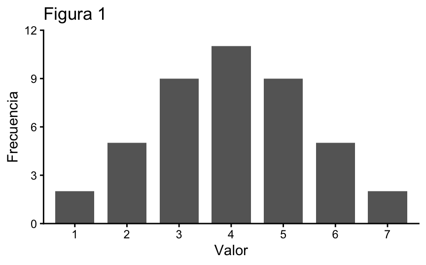

Figure 1

La distribución parece:

A. Sesgada a la izquierda

B. Uniforme

C. Simétrica

D. Sesgada a la derecha

### 25.

Observe la Figura 2.

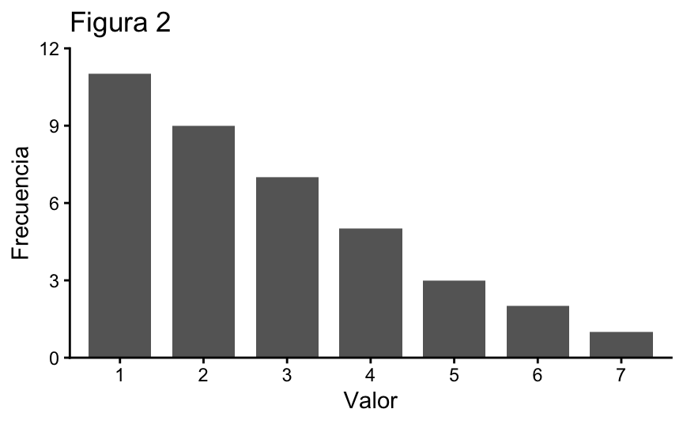

Figure 2

La distribución parece:

A. Sesgada a la izquierda

B. Bimodal

C. Simétrica

D. Sesgada a la derecha

### 26.

Observe la Figura 3.

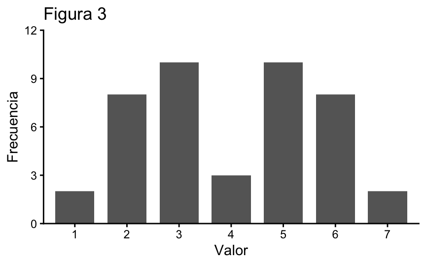

Figure 3

La distribución es:

A. Uniforme

B. Simétrica con una sola moda

C. Bimodal

D. Sesgada a la derecha

### 27.

Observe la Figura 4.

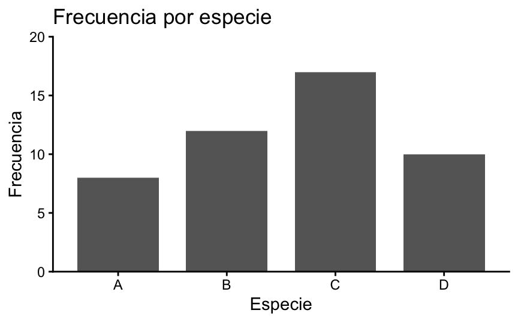

Figure 4

¿Cuál categoría presenta la frecuencia más alta?

A. Especie C

B. Especie D

C. Especie A

D. Especie B

# VI. Tendencia Central

### 28.

La media representa:

A. El valor más frecuente

B. El promedio aritmético de las observaciones

C. El valor central de los datos ordenados

D. La diferencia entre el mayor y el menor valor

### 29.

La mediana representa:

A. El promedio de las observaciones.

B. El valor más frecuente.

C. El valor central cuando las observaciones se ordenan.

D. Una medida de dispersión.

### 30.

La moda representa:

A. El valor que ocurre con mayor frecuencia.

B. El valor central de los datos.

C. El promedio aritmético.

D. La dispersión de los datos.

### 31.

¿Cuál es la media de 2, 4 y 6?

A. 2

B. 3

C. 4

D. 6

### 32.

¿Cuál es la mediana de 1, 3, 5, 7 y 9?

A. 3

B. 5

C. 6

D. 7

# VII. Variabilidad y Fórmulas

### 33.

El rango se calcula como:

A. Media − Mediana

B. Máximo − Mínimo

C. Suma de todos los valores

D. Media ÷ n

### 34.

Si todos los valores observados son iguales, el rango es:

A. Igual a la media

B. 1

C. No puede calcularse

D. 0

### 35.

Observe la Figura 5.

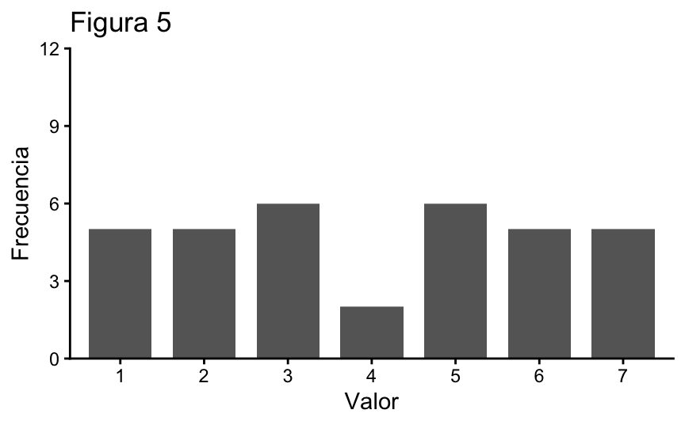

Figure 5

Una varianza grande indica:

A. Los datos presentan poca dispersión

B. Los datos están concentrados cerca de la media

C. Los datos presentan mayor dispersión

D. La distribución es necesariamente asimétrica

### 36.

La fórmula

$$\bar{x}=\frac{\sum x}{n}$$

calcula:

A. Mediana

B. Moda

C. Media

D. Rango

### 37.

La fórmula

$$s^2=\frac{\sum(x_i-\bar{x})^2}{n-1}$$

se utiliza para medir:

A. La tendencia central de los datos

B. La frecuencia relativa

C. La dispersión de los datos respecto a la media

D. La asimetría de una distribución

### 38.

La fórmula

$$\frac{f}{n}\times100$$

se utiliza para calcular:

A. Frecuencia porcentual

B. Varianza

C. Media

D. Mediana

# VIII. Respuesta Corta

### 39. (2 puntos)

Explique brevemente la diferencia entre una población y una muestra.

### 40. (2 puntos)

Mencione una ventaja del muestreo aleatorio.